# Puget Sound observed pH time series decomposition

M. W. Beck

```r
library(knitr)
library(tidyverse)
library(readxl)
library(here)
library(lubridate)
library(oce)
library(mgcv)

opts_chunk$set(warning = FALSE, message = FALSE)
```

## WDNR buoy edge, center

Import, format data and run decomposition.

```r
obsdat <- read.csv(here('data/raw/2018 WDNR pH sensor data - 2018 WDNR pH sensor data.csv.csv')) %>%
  select(Date, TimePST, matches('pH')) %>%
  gather('loc', 'pH', -Date, -TimePST) %>%
  mutate(
    loc = case_when(
      grepl('Buoy', loc) ~ 'Buoy',
      grepl('Edge', loc) ~ 'Farm edge',
      grepl('Mid', loc) ~ 'Farm center'
    ),
    loc = factor(loc, levels = c('Buoy', 'Farm edge', 'Farm center'))
  ) %>%
  unite('datetime', Date, TimePST, sep = ' ') %>%
  mutate(
    datetime = mdy_hms(datetime, tz = 'Pacific/Pitcairn')
  ) %>%
  filter(as.Date(datetime) <= ymd('2018-07-07') & as.Date(datetime) >= ymd('2018-05-25'))

# decomp
phres <- obsdat %>%
  group_by(loc) %>%
  nest() %>%
  mutate(
    annprd = pmap(list(loc, data), function(loc, data){

      dat <- data %>%
        filter(minute(datetime) == 0) %>%
        mutate(dectime = decimal_date(datetime))

      # annmod <- lm(pH ~ sin(2*pi*dectime) + cos(2*pi*dectime), data = dat, na.action = na.exclude)

      out <- dat %>%
        mutate(
          ph_ann = stats::filter(pH, filter = rep(1, 24) / 24, sides = 1, method = 'convolution'),#predict(annmod),
          ph_anndtrn = pH - ph_ann
        )

      return(out)

    }),
    sumval = map(annprd, function(annprd){

      out <- tibble(
        avev = mean(annprd$pH, na.rm = T),
        minv = min(annprd$pH, na.rm = T),
        maxv = max(annprd$pH, na.rm = T),
        sdv = sd(annprd$pH, na.rm = T)
      )

      return(out)

    }),
    dlyprd = map(annprd, function(annprd){

      datsub <- annprd %>%
        mutate(
          decdays =  365 * (decimal_date(datetime) - max(year(datetime))),
          hrs = hour(datetime)
        )

      dlymod <- lm(ph_anndtrn ~ sin(2*pi*decdays) + cos(2*pi*decdays), data = datsub, na.action = na.exclude)
      # dlymod <- gam(ph_anndtrn ~ s(hrs, bs = 'cc'), data = datsub, na.action = na.exclude)

      dlyprd <- datsub %>%
        mutate(
          ph_dly = predict(dlymod),
          ph_dlydtrn = ph_anndtrn - ph_dly
        )

      datsl <- as.sealevel(elevation = dlyprd$ph_dlydtrn, time = dlyprd$datetime)

      constituents <- c('M2', 'S2', 'N2', 'K1', 'O1')

      # loop through tidal components, predict each with tidem
      preds <- sapply(constituents, function(x){

        mod <- tidem(t = datsl, constituent = x)
        pred <- predict(mod)
        pred - mean(pred, na.rm = T)

      })

      out <- dlyprd %>%
        mutate(
          K1 = data.frame(preds)[['K1']],
          O1 = data.frame(preds)[['O1']],
          S2 = data.frame(preds)[['S2']],
          N2 = data.frame(preds)[['N2']],
          M2 = data.frame(preds)[['M2']]
        ) %>%
        rowwise() %>%
        mutate(
          ph_mod = sum(ph_ann, ph_dly, K1, O1, S2, N2, M2)
        ) %>%
        ungroup()

      return(out)

    }),
    rngs = pmap(list(dlyprd, annprd), function(dlyprd, annprd){

      rngs <- dlyprd %>%
        select(ph_dly, K1, O1, S2, N2, M2) %>%
        mutate(
          ph_dly = ph_dly - mean(ph_dly, na.rm = T)
        ) %>%
        gather('var', 'val') %>%
        group_by(var) %>%
        summarise(
          minv = min(val, na.rm = T),
          maxv = max(val, na.rm = T),
          .groups = 'drop'
        )

      ann <- range(annprd$ph_ann, na.rm = T) %>%
        diff %>%
        `/`(2) %>%
        tibble(
          var = 'ann',
          minv = .,
          maxv = .
        ) %>%
        mutate(
          minv = -1 * minv
        )

      out <- bind_rows(rngs, ann) %>%
        mutate(
          var = factor(var,
                       levels = c('ann', 'ph_dly', 'K1', 'O1', 'M2', 'S2', 'N2'),
                       labels = c('Annual', 'Daily', 'K1', 'O1', 'M2', 'S2', 'N2')
          )
        )

      return(out)

    }),
    dlyrng = map(dlyprd, function(dlyprd){

      out <- dlyprd %>%
        mutate(
          dy = yday(datetime)
        ) %>%
        group_by(dy) %>%
        summarise(
          minph = ifelse(length(na.omit(ph_mod)) > 0, min(ph_mod, na.rm = T), NA),
          maxph = ifelse(length(na.omit(ph_mod)) > 0, max(ph_mod, na.rm = T), NA),
          .groups = 'drop'
        ) %>%
        mutate(
          phdff = (maxph - minph) / 2
        )

      return(out)

    })
  )
```

pH time series for all locations plus estimated annual component.

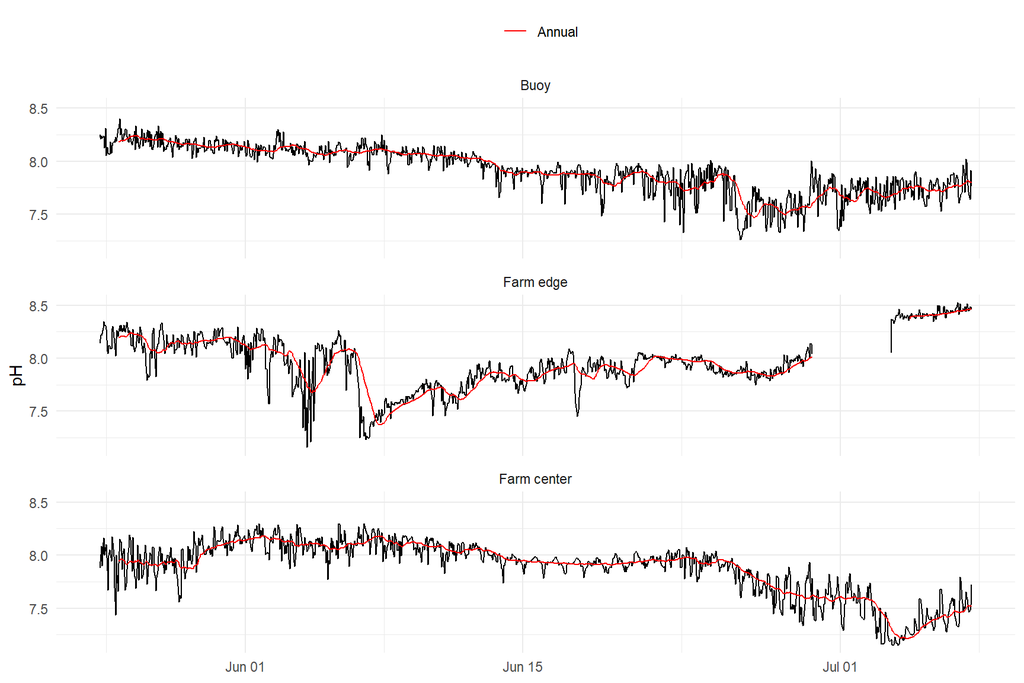

```r
annplo <- phres %>%
  select(annprd) %>%
  unnest('annprd')

p <- ggplot(annplo, aes(x = datetime, y = pH)) +
  geom_line() +
  geom_line(aes(y = ph_ann, col = 'Annual')) +
  scale_color_manual(values = 'red') +
  facet_wrap(~loc, ncol = 1) +
  theme_minimal() +
  theme(
    legend.position = 'top',
    legend.title = element_blank()
  ) +
  labs(
    x = NULL
  )
p
```

pH time series for all locations 24 hour smooth detrended.

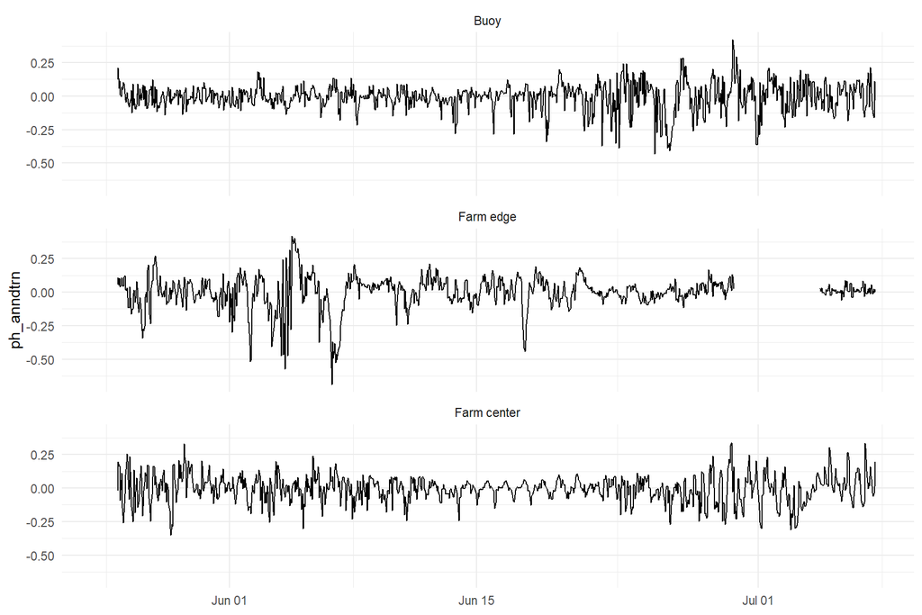

```r
p <- ggplot(annplo, aes(x = datetime, y = ph_anndtrn)) +
  geom_line() +
  facet_wrap(~loc, ncol = 1) +
  theme_minimal() +
  theme(
    legend.position = 'top',
    legend.title = element_blank()
  ) +
  labs(
    x = NULL
  )
p
```

pH time series for all locations 24 hour smooth detrended, daily sine wave.

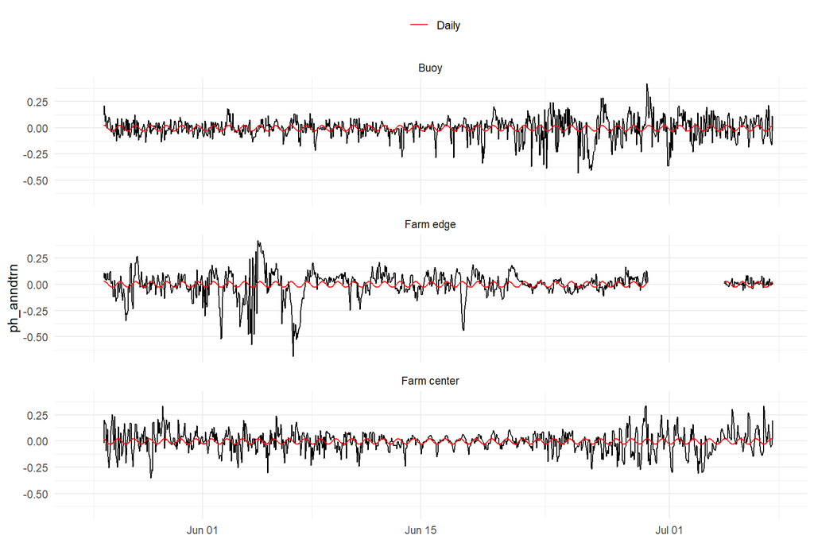

```r
dlyplo <- phres %>%
  select(dlyprd) %>%
  unnest('dlyprd')

p <- ggplot(dlyplo, aes(x = datetime, y = ph_anndtrn)) +
  geom_line() +
  geom_line(aes(y = ph_dly, col = 'Daily')) +
  scale_color_manual(values = 'red') +
  facet_wrap(~loc, ncol = 1) +
  theme_minimal() +
  theme(
    legend.position = 'top',
    legend.title = element_blank()
  ) +
  labs(
    x = NULL
  )
p
```

pH time series for all locations, observed and modelled.

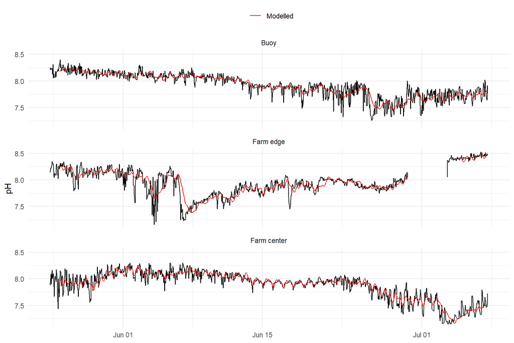

```r
dlyplo <- phres %>%
  select(dlyprd) %>%
  unnest('dlyprd')

p <- ggplot(dlyplo, aes(x = datetime, y = pH)) +
  geom_line() +
  geom_line(aes(y = ph_mod, col = 'Modelled')) +
  scale_color_manual(values = 'red') +
  facet_wrap(~loc, ncol = 1) +
  theme_minimal() +
  theme(
    legend.position = 'top',
    legend.title = element_blank()
  ) +
  labs(
    x = NULL
  )
p
```

Estimated amplitudes for annual, daily, and tidal components for each location.

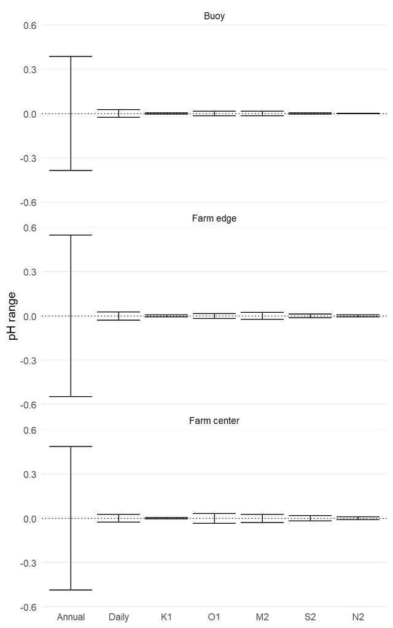

```r
rngplo <- phres %>%
  select(rngs) %>%
  unnest('rngs')

ggplot(rngplo, aes(x = var)) +
  geom_errorbar(aes(ymin = minv, ymax = maxv)) +
  geom_hline(yintercept = 0, linetype = 'dotted') +
  facet_wrap(~loc, ncol = 1) +
  theme_minimal() +
  theme(
    panel.grid.major.x = element_blank(),
    panel.grid.minor.y = element_blank(),
    panel.grid.minor.x = element_blank()
  ) +
  labs(
    y = 'pH range',
    x = NULL
  )
```

Estimated amplitudes for annual, daily, and tidal components for each location, alternative plot.

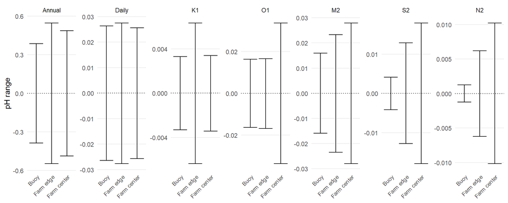

```r
rngplo <- phres %>%
  select(rngs) %>%
  unnest('rngs')

ggplot(rngplo, aes(x = loc)) +
  geom_errorbar(aes(ymin = minv, ymax = maxv)) +
  geom_hline(yintercept = 0, linetype = 'dotted') +
  theme_minimal() +
  facet_wrap(~var, scales = 'free_y', ncol = 7) +
  theme(
    panel.grid.major.x = element_blank(),
    panel.grid.minor.y = element_blank(),
    panel.grid.minor.x = element_blank(),
    axis.text.x = element_text(angle = 45, hjust = 1, size = 8)
  ) +
  labs(
    y = 'pH range',
    x = NULL
  )
```

Distribution of total range of pH across days.

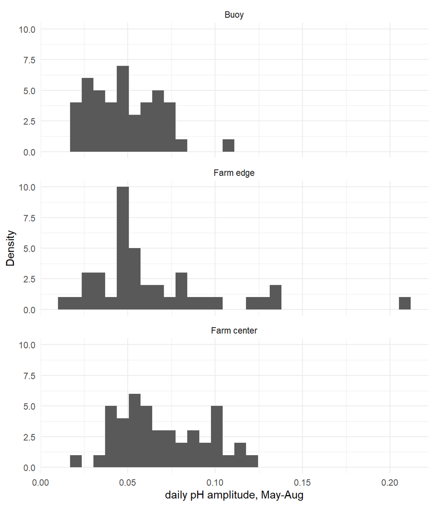

```r
dlyrngplo <- phres %>%
  select(dlyrng) %>%
  unnest('dlyrng')

ggplot(dlyrngplo, aes(x = phdff)) +
  geom_histogram() +
  facet_wrap(~loc, ncol = 1) +
  theme_minimal() +
  labs(
    x = 'daily pH amplitude, May-Aug',
    y = 'Density'
  )
```

## PMEL

Import, format data and run decomposition.

```r
subdts <- ymd(c('2018-05-25', '2018-07-06'))

# original data
obsdat1 <- read.csv(here('data/raw/SB1_1m_PMEL_2017-2018.csv')) %>%
  group_by(year, month, day, hour) %>%
  sample_n(1) %>% # sometimes there's more than one measurement per hour
  ungroup %>%
  unite('date', month, day, year, sep = '-') %>%
  unite('time', hour, min, sec, sep = ':') %>%
  unite('datetime', date, time, sep = ' ') %>%
  mutate(
    datetime = mdy_hms(datetime, tz = 'UTC'),
    datetime = with_tz(datetime, tz = 'Pacific/Pitcairn'),
    datetime = floor_date(datetime, unit = 'hour'),
    typ = 'original'
  ) %>%
  filter(as.Date(datetime) <= subdts[2] & as.Date(datetime) >= subdts[1])

# resampled
obsdat2 <- read.csv(here('data/raw/SB1_1m_PMEL_2018_resampled.csv')) %>%
  unite('date', month, day, year, sep = '-') %>%
  unite('time', hour, min, sec, sep = ':') %>%
  unite('datetime', date, time, sep = ' ') %>%
  mutate(
    datetime = mdy_hms(datetime, tz = 'UTC'),
    datetime = with_tz(datetime, tz = 'Pacific/Pitcairn'),
    typ = 'resampled'
  ) %>%
  filter(as.Date(datetime) <= subdts[2] & as.Date(datetime) >= subdts[1]) %>%
  filter(minute(datetime) == 0) # subset to hour

# combine
obsdat <- bind_rows(obsdat1, obsdat2) %>%
  rename(pH = pH_tot)

# decomp
phres <- obsdat %>%
  group_by(typ) %>%
  nest() %>%
  mutate(
    annprd = pmap(list(typ, data), function(typ, data){

      dat <- data %>%
        mutate(dectime = decimal_date(datetime))

      # annmod <- lm(pH ~ sin(2*pi*dectime) + cos(2*pi*dectime), data = dat, na.action = na.exclude)

      out <- dat %>%
        mutate(
          ph_ann = stats::filter(pH, filter = rep(1, 24) / 24, sides = 1, method = 'convolution'),#predict(annmod),
          ph_anndtrn = pH - ph_ann
        )

      return(out)

    }),
    sumval = map(annprd, function(annprd){

      out <- tibble(
        avev = mean(annprd$pH, na.rm = T),
        minv = min(annprd$pH, na.rm = T),
        maxv = max(annprd$pH, na.rm = T),
        sdv = sd(annprd$pH, na.rm = T)
      )

      return(out)

    }),
    dlyprd = map(annprd, function(annprd){

      datsub <- annprd %>%
        mutate(
          decdays =  365 * (decimal_date(datetime) - max(year(datetime))),
          hrs = hour(datetime)
        )

      dlymod <- lm(ph_anndtrn ~ sin(2*pi*decdays) + cos(2*pi*decdays), data = datsub, na.action = na.exclude)
      # dlymod <- gam(ph_anndtrn ~ s(hrs, bs = 'cc'), data = datsub, na.action = na.exclude)

      dlyprd <- datsub %>%
        mutate(
          ph_dly = predict(dlymod),
          ph_dlydtrn = ph_anndtrn - ph_dly
        )

      datsl <- as.sealevel(elevation = dlyprd$ph_dlydtrn, time = dlyprd$datetime)

      constituents <- c('M2', 'S2', 'N2', 'K1', 'O1')

      # loop through tidal components, predict each with tidem
      preds <- sapply(constituents, function(x){

        mod <- tidem(t = datsl, constituent = x)
        pred <- predict(mod)
        pred - mean(pred, na.rm = T)

      })

      out <- dlyprd %>%
        mutate(
          K1 = data.frame(preds)[['K1']],
          O1 = data.frame(preds)[['O1']],
          S2 = data.frame(preds)[['S2']],
          N2 = data.frame(preds)[['N2']],
          M2 = data.frame(preds)[['M2']]
        ) %>%
        rowwise() %>%
        mutate(
          ph_mod = sum(ph_ann, ph_dly, K1, O1, S2, N2, M2)
        ) %>%
        ungroup()

      return(out)

    }),
    rngs = pmap(list(dlyprd, annprd), function(dlyprd, annprd){

      rngs <- dlyprd %>%
        select(ph_dly, K1, O1, S2, N2, M2) %>%
        mutate(
          ph_dly = ph_dly - mean(ph_dly, na.rm = T)
        ) %>%
        gather('var', 'val') %>%
        group_by(var) %>%
        summarise(
          minv = min(val, na.rm = T),
          maxv = max(val, na.rm = T),
          .groups = 'drop'
        )

      ann <- range(annprd$ph_ann, na.rm = T) %>%
        diff %>%
        `/`(2) %>%
        tibble(
          var = 'ann',
          minv = .,
          maxv = .
        ) %>%
        mutate(
          minv = -1 * minv
        )

      out <- bind_rows(rngs, ann) %>%
        mutate(
          var = factor(var,
                       levels = c('ann', 'ph_dly', 'K1', 'O1', 'M2', 'S2', 'N2'),
                       labels = c('Annual', 'Daily', 'K1', 'O1', 'M2', 'S2', 'N2')
          )
        )

      return(out)

    }),
    dlyrng = map(dlyprd, function(dlyprd){

      out <- dlyprd %>%
        mutate(
          dy = yday(datetime)
        ) %>%
        group_by(dy) %>%
        summarise(
          minph = ifelse(length(na.omit(ph_mod)) > 0, min(ph_mod, na.rm = T), NA),
          maxph = ifelse(length(na.omit(ph_mod)) > 0, max(ph_mod, na.rm = T), NA),
          .groups = 'drop'
        ) %>%
        mutate(
          phdff = (maxph - minph) / 2
        )

      return(out)

    })
  )
```

pH time series for the two datasets plus estimated annual component.

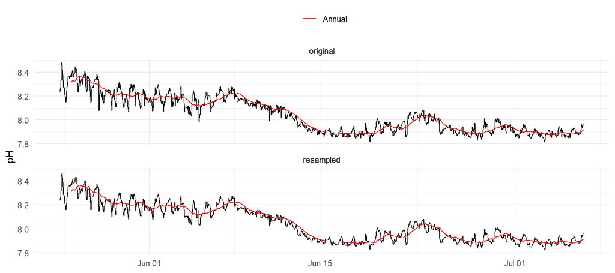

```r
annplo <- phres %>%
  select(annprd) %>%
  unnest('annprd')

p <- ggplot(annplo, aes(x = datetime, y = pH)) +
  geom_line() +
  geom_line(aes(y = ph_ann, col = 'Annual')) +
  scale_color_manual(values = 'red') +
  facet_wrap(~typ, ncol = 1) +
  theme_minimal() +
  theme(
    legend.position = 'top',
    legend.title = element_blank()
  ) +
  labs(
    x = NULL
  )
p
```

pH time series for the two datasets 24 hour smooth detrended.

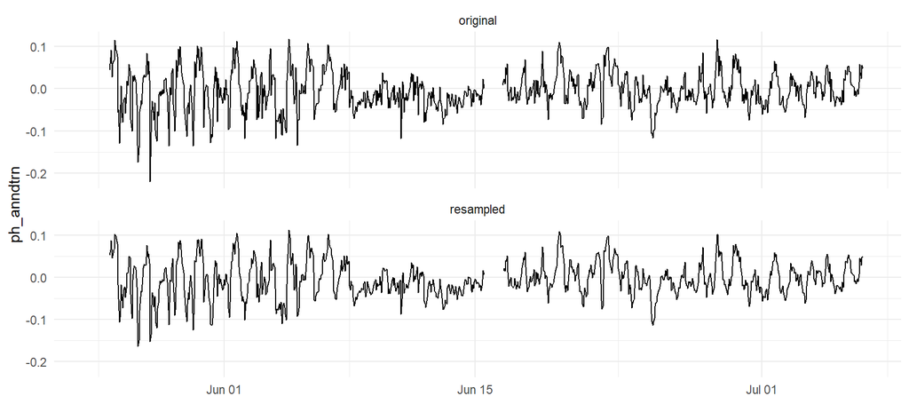

```r
p <- ggplot(annplo, aes(x = datetime, y = ph_anndtrn)) +
  geom_line() +
  facet_wrap(~typ, ncol = 1) +
  theme_minimal() +
  theme(
    legend.position = 'top',
    legend.title = element_blank()
  ) +
  labs(
    x = NULL
  )
p
```

pH time series for the two datasets 24 hour smooth detrended, daily sine wave.

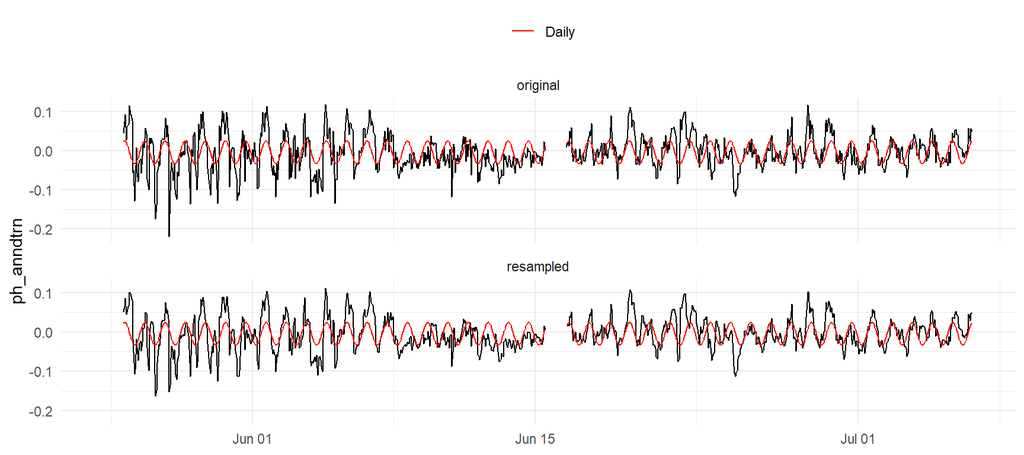

```r
dlyplo <- phres %>%
  select(dlyprd) %>%
  unnest('dlyprd')

p <- ggplot(dlyplo, aes(x = datetime, y = ph_anndtrn)) +
  geom_line() +
  geom_line(aes(y = ph_dly, col = 'Daily')) +
  scale_color_manual(values = 'red') +
  facet_wrap(~typ, ncol = 1) +
  theme_minimal() +
  theme(
    legend.position = 'top',
    legend.title = element_blank()
  ) +
  labs(
    x = NULL
  )
p
```

pH time series for the two datasets, observed and modelled.

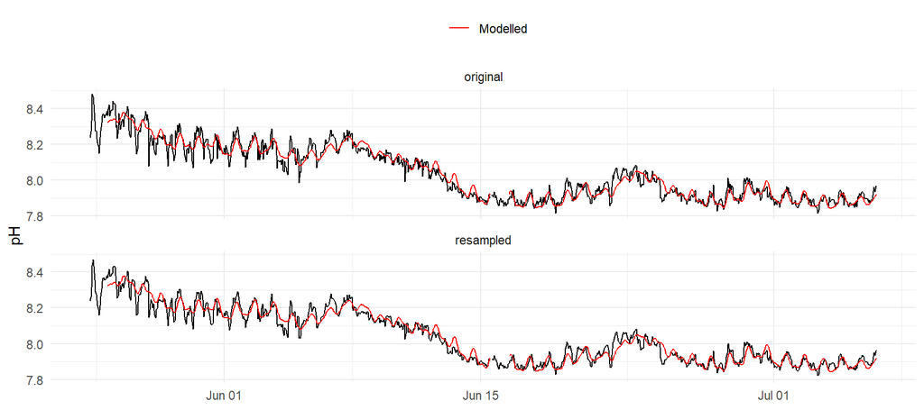

```r
dlyplo <- phres %>%
  select(dlyprd) %>%
  unnest('dlyprd')

p <- ggplot(dlyplo, aes(x = datetime, y = pH)) +
  geom_line() +
  geom_line(aes(y = ph_mod, col = 'Modelled')) +
  scale_color_manual(values = 'red') +
  facet_wrap(~typ, ncol = 1) +
  theme_minimal() +
  theme(
    legend.position = 'top',
    legend.title = element_blank()
  ) +
  labs(
    x = NULL
  )
p
```

Estimated amplitudes for annual, daily, and tidal components for the two datasets.

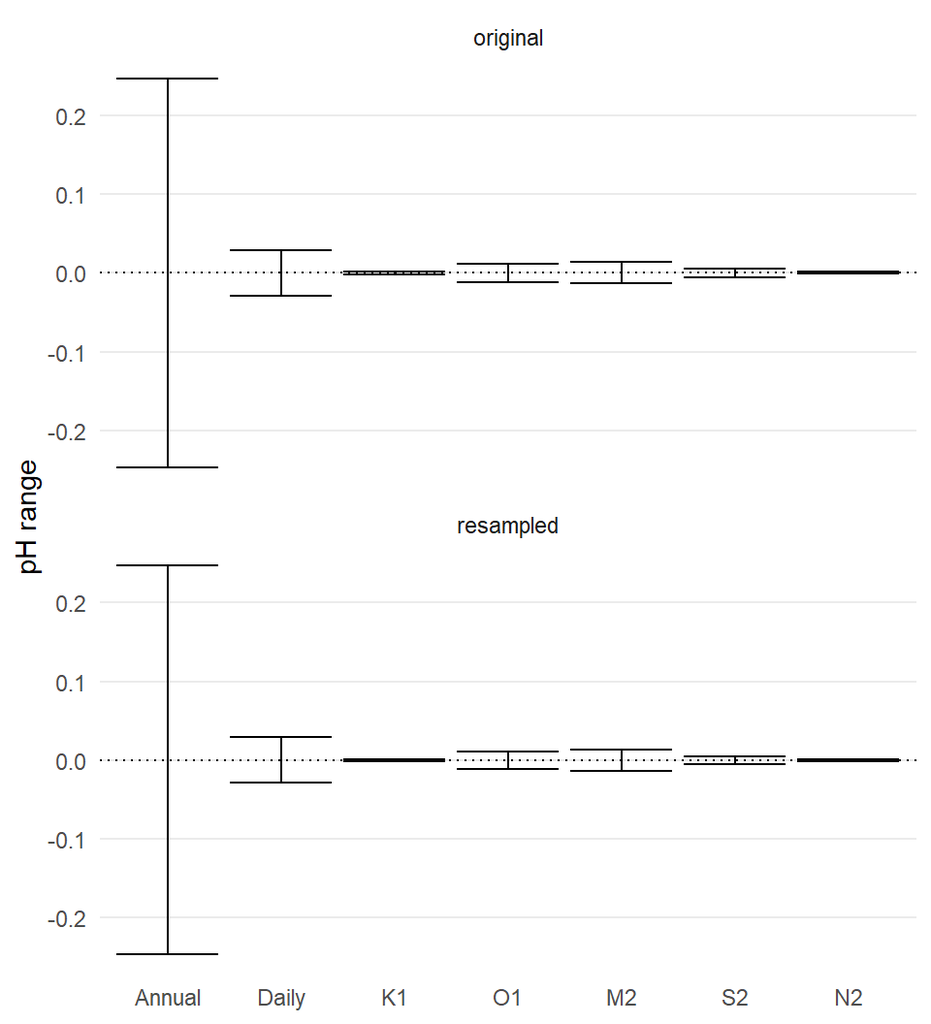

```r
rngplo <- phres %>%
  select(rngs) %>%
  unnest('rngs')

ggplot(rngplo, aes(x = var)) +
  geom_errorbar(aes(ymin = minv, ymax = maxv)) +
  geom_hline(yintercept = 0, linetype = 'dotted') +
  facet_wrap(~typ, ncol = 1) +
  theme_minimal() +
  theme(
    panel.grid.major.x = element_blank(),
    panel.grid.minor.y = element_blank(),
    panel.grid.minor.x = element_blank()
  ) +
  labs(
    y = 'pH range',
    x = NULL
  )
```

Estimated amplitudes for annual, daily, and tidal components for the two datasets, alternative plot.

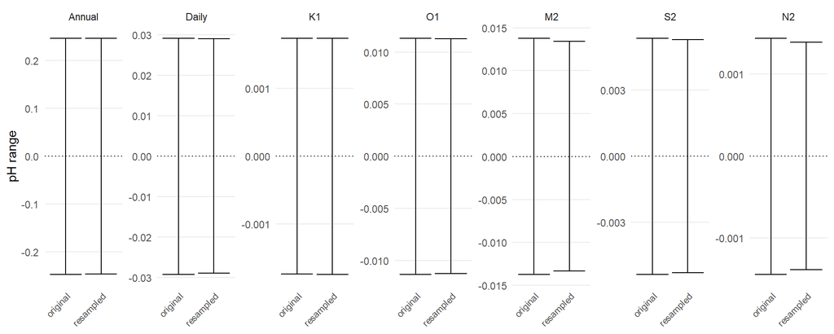

```r
rngplo <- phres %>%
  select(rngs) %>%
  unnest('rngs')

ggplot(rngplo, aes(x = typ)) +
  geom_errorbar(aes(ymin = minv, ymax = maxv)) +
  geom_hline(yintercept = 0, linetype = 'dotted') +
  theme_minimal() +
  facet_wrap(~var, scales = 'free_y', ncol = 7) +
  theme(
    panel.grid.major.x = element_blank(),
    panel.grid.minor.y = element_blank(),
    panel.grid.minor.x = element_blank(),
    axis.text.x = element_text(angle = 45, hjust = 1, size = 8)
  ) +
  labs(
    y = 'pH range',
    x = NULL
  )
```

Distribution of total range of pH across days.

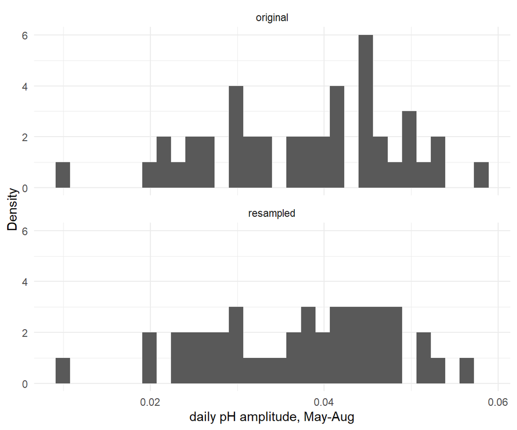

```r
dlyrngplo <- phres %>%
  select(dlyrng) %>%
  unnest('dlyrng')

ggplot(dlyrngplo, aes(x = phdff)) +
  geom_histogram() +
  facet_wrap(~typ, ncol = 1) +
  theme_minimal() +
  labs(
    x = 'daily pH amplitude, May-Aug',
    y = 'Density'
  )
```